# Scatter, Box, and Violin Plots

David Gerbing

**lessR** provides many versions of a scatter plot with its `Plot()` function for one or two variables with an option to provide a separate scatterplot for each level of one or two categorical variables. Access all scatterplots with the same simple syntax. The first variable listed without a parameter name, the `x` parameter, is plotted along the x-axis. Any second variable listed without a parameter name, the `y` parameter, is plotted along the y-axis. Each parameter may be represented by a continuous or categorical variable, a single variable or a vector of variables.

## The Data

Illustrate with the Employee data included as part of **lessR**.

```r
d <- Read("Employee")
```

```
##
## >>> Suggestions
## Recommended binary format for data files: feather
##   Create with Write(d, "your_file", format="feather")
## More details about your data, Enter:  details()  for d, or  details(name)
##
## Data Types
## ------------------------------------------------------------
## character: Non-numeric data values
## integer: Numeric data values, integers only
## double: Numeric data values with decimal digits
## ------------------------------------------------------------
##
##     Variable                  Missing  Unique
##         Name     Type  Values  Values  Values   First and last values
## ------------------------------------------------------------------------------------------
##  1     Years   integer     36       1      16   7  NA  7 ... 1  2  10
##  2    Gender character     37       0       2   M  M  W ... W  W  M
##  3      Dept character     36       1       5   ADMN  SALE  FINC ... MKTG  SALE  FINC
##  4    Salary    double     37       0      37   53788.26  94494.58 ... 56508.32  57562.36
##  5    JobSat character     35       2       3   med  low  high ... high  low  high
##  6      Plan   integer     37       0       3   1  1  2 ... 2  2  1
##  7       Pre   integer     37       0      27   82  62  90 ... 83  59  80
##  8      Post   integer     37       0      22   92  74  86 ... 90  71  87
## ------------------------------------------------------------------------------------------
```

As an option, **lessR** also supports variable labels. The labels are displayed on both the text and visualization output. Each displayed label consists of the variable name juxtaposed with the corresponding label. Create the table formatted as two columns. The first column is the variable name and the second column is the corresponding variable label. Not all variables need to be entered into the table. The table can be stored as either a `csv` file or an Excel file.

Read the variable label file into the *l* data frame, currently the only permissible name for the label file.

```r
l <- rd("Employee_lbl")
```

```
##
## >>> Suggestions
## Recommended binary format for data files: feather
##   Create with Write(d, "your_file", format="feather")
## More details about your data, Enter:  details()  for d, or  details(name)
##
## Data Types
## ------------------------------------------------------------
## character: Non-numeric data values
## ------------------------------------------------------------
##
##     Variable                  Missing  Unique
##         Name     Type  Values  Values  Values   First and last values
## ------------------------------------------------------------------------------------------
##  1     label character      8       0       8   Time of Company Employment ... Test score on legal issues after instruction
## ------------------------------------------------------------------------------------------
```

Display the available labels.

```r
l
```

```
##                                                label
## Years                     Time of Company Employment
## Gender                                  Man or Woman
## Dept                             Department Employed
## Salary                           Annual Salary (USD)
## JobSat            Satisfaction with Work Environment
## Plan             1=GoodHealth, 2=GetWell, 3=BestCare
## Pre    Test score on legal issues before instruction
## Post    Test score on legal issues after instruction
```

## Continuous Variables

### Two Variables

A typical scatterplot visualizes the relationship of two continuous variables, here *Years* worked at a company, and annual *Salary*. Following is the function call to `Plot()` for the default visualization.

Because *d* is the default name of the data frame that contains the variables for analysis, the `data` parameter that names the input data frame need not be specified. That is, no need to specify `data=d`, though this parameter can be explicitly included in the function call if desired.

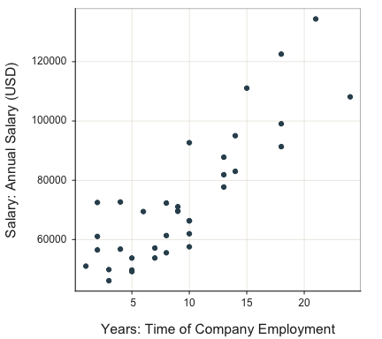

```
## --- Pearson's product-moment correlation ---
##
## Years: Time of Company Employment
## Salary: Annual Salary (USD)
##
## Number of paired values with neither missing, n = 36
## Sample Correlation of Years and Salary: r = 0.852
##
## Hypothesis Test of 0 Correlation:  t = 9.501,  df = 34,  p-value = 0.000
## 95% Confidence Interval for Correlation:  0.727 to 0.923
##
```

```r
Plot(Years, Salary)
```

Enhance the default scatterplot with parameter `enhance`. The visualization includes the mean of each variable indicated by the respective line through the scatterplot, the 95% confidence ellipse, labeled outliers, least-squares regression line with 95% confidence interval, and the corresponding regression line with the outliers removed.

```
## [Ellipse with Murdoch and Chow's function ellipse from their ellipse package]
```

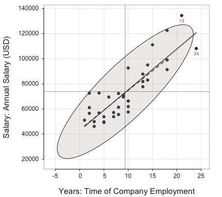

```
## --- Pearson's product-moment correlation ---
##
## Years: Time of Company Employment
## Salary: Annual Salary (USD)
##
## Number of paired values with neither missing, n = 36
## Sample Correlation of Years and Salary: r = 0.852
##
## Hypothesis Test of 0 Correlation:  t = 9.501,  df = 34,  p-value = 0.000
## 95% Confidence Interval for Correlation:  0.727 to 0.923
##
##
## >>> Outlier analysis with Mahalanobis Distance
##
##   MD  ID
## ----- -----
## 8.14  18
## 7.84  34
##
## 5.63  31
## 5.58  19
## 3.75   4
## ...  ...
```

```r
Plot(Years, Salary, enhance=TRUE)
```

A variety of fit lines can be plotted. The available values: `"loess"` for general non-linear fit, `"lm"` for linear least squares, `"null"` for the null (flat line) model, `"exp"` for the exponential growth and decay, `"quad"` for the quadratic model, and `power` for the general power beyond 2. Setting `fit` to `TRUE` plots the `"loess"` line. With the value of `power`, specify the value of the root with parameter `fit_power`.

Here, plot the general non-linear fit. For emphasis set `plot_errors` to `TRUE` to plot the residuals from the line. The sum of the squared errors is displayed to facilitate the comparison of different models.

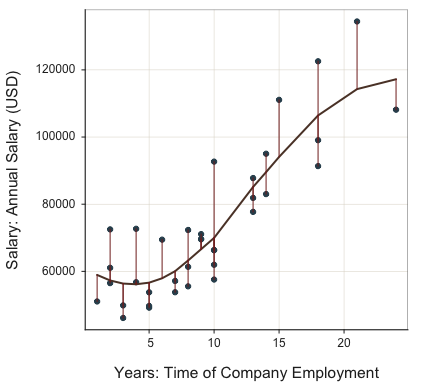

```
##
## Fit: Mean Squared Error, MSE = 100,834,065
##
```

```r
Plot(Years, Salary, fit="loess", plot_errors=TRUE)
```

Next, plot the exponential fit and show the residuals from the exponential curve. These data are approximately linear so the exponential curve does not vary far from a straight line. The function displays the corresponding sum of squared errors to assist in comparing various models to each other.

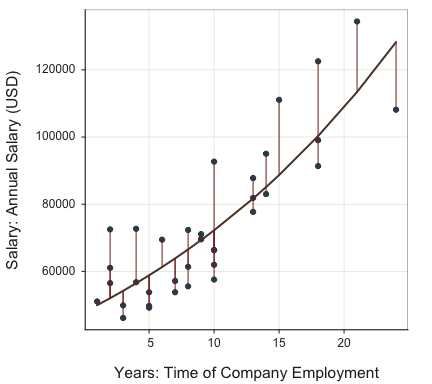

```
##
##  Regressed linearized data of transformed data values of Salary with log()
##  For predicted values, back transform with exp() of regression model
##
##  Line: b0 = 10.777   b1 = 0.041    Fit: MSE = 0.022   Rsq = 0.722
##
```

```r
Plot(Years, Salary, fit="exp", plot_errors=TRUE)
```

### Three Variables

Map a continuous variable, such as *Pre*, to the plotted points with the `size` parameter, a bubble plot.

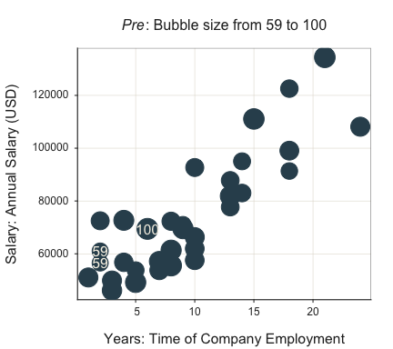

```
## --- Pearson's product-moment correlation ---
##
## Years: Time of Company Employment
## Salary: Annual Salary (USD)
##
## Number of paired values with neither missing, n = 36
## Sample Correlation of Years and Salary: r = 0.852
##
## Hypothesis Test of 0 Correlation:  t = 9.501,  df = 34,  p-value = 0.000
## 95% Confidence Interval for Correlation:  0.727 to 0.923
##
##
## Some Parameter values (can be manually set)
## -------------------------------------------------------
## radius: 0.12    size of largest bubble
## power: 0.50     relative bubble sizes
```

```r
Plot(Years, Salary, size=Pre)
```

Indicate multiple variables to plot along either axis with a vector defined according to the base R function `c()`. Plot the linear model for each variable according to the `fit` parameter set to `"lm"`. By default, when multiple lines are plotted on the same panel, the confidence interval is turned off by internally setting the parameter `fit_se` set to `0`. Explicitly override this parameter value as needed.

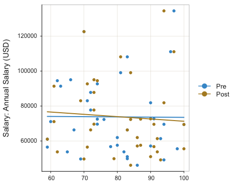

```
## --- Pearson's product-moment correlation ---
##
## Post: Test score on legal issues after instruction
## Salary: Annual Salary (USD)
##
## Number of paired values with neither missing, n = 37
## Sample Correlation of Post and Salary: r = -0.070
##
## Hypothesis Test of 0 Correlation:  t = -0.416,  df = 35,  p-value = 0.680
## 95% Confidence Interval for Correlation:  -0.385 to 0.260
##
```

```r
Plot(c(Pre, Post), Salary, fit="lm", fit_se=0)
```

### Scatterplot Matrix

Multiple variables for the first parameter value, `x`, and no values for `y`, plot as a scatterplot matrix. Pass a single vector, such as defined by `c()`. Request the non-linear fit line and corresponding confidence interval by specifying `TRUE` or `loess` for the `fit` parameter. Request a linear fit line with the value of `"lm"`.

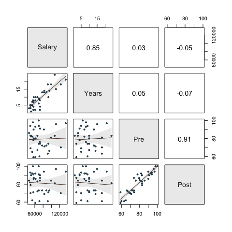

```r
Plot(c(Salary, Years, Pre, Post), fit="lm")
```

### Smoothed and Binned Scatterplots

Smoothing and binning are two procedures for visualizing a relationship with many data values.

To obtain a larger data set, in this example generate random data with base R `rnorm()`, then plot. `Plot()` first checks the presence of the specified variables in the global environment (workspace). If not there, then from a data frame, of which the default value is *d*. Here, randomly generate values from normal populations for *x* and *y* in the workspace.

```
## >>> Note: x is not in a data frame (table)
## >>> Note: y is not in a data frame (table)
```

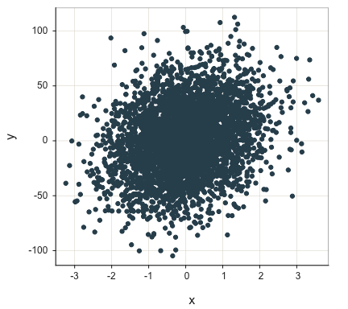

```
## --- Pearson's product-moment correlation ---
##
## Number of paired values with neither missing, n = 4000
## Sample Correlation of x and y: r = 0.251
##
## Hypothesis Test of 0 Correlation:  t = 16.397,  df = 3998,  p-value = 0.000
## 95% Confidence Interval for Correlation:  0.222 to 0.280
##
```

```r
set.seed(13)
x=rnorm(4000)
y= 8*x + rnorm(4000,1, 30)
Plot(x, y)
```

With large data sets, even for continuous variables there can be much over-plotting of points. One strategy to address this issue smooths the scatterplot by turning on the `smooth` parameter. The individual points superimposed on the smoothed plot are potential outliers. The default number of plotted outliers is 100. Turn off the plotting of outliers completely by setting parameter `smooth_points` to `0`. Show the linear trend with `fit` set to `"lm"`.

```
## >>> Note: x is not in a data frame (table)
## >>> Note: y is not in a data frame (table)
```

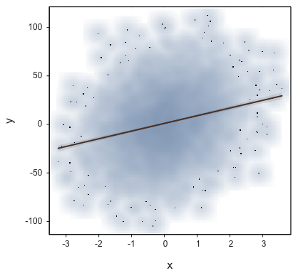

```
## --- Pearson's product-moment correlation ---
##
## Number of paired values with neither missing, n = 4000
## Sample Correlation of x and y: r = 0.251
##
## Hypothesis Test of 0 Correlation:  t = 16.397,  df = 3998,  p-value = 0.000
## 95% Confidence Interval for Correlation:  0.222 to 0.280
##
##
##  Line: b0 = 1.030687568   b1 = 7.919636637    Fit: MSE = 917.032   Rsq = 0.063
##
```

```r
Plot(x, y, smooth=TRUE, fit="lm")
```

Another strategy for alleviating over-plotting makes the fill color mostly transparent with the `transparency` parameter, or turn off completely by setting `fill` to `"off"`. The closer the value of `trans` is to 1, the more transparent is the fill.

```
## >>> Note: x is not in a data frame (table)
## >>> Note: y is not in a data frame (table)
```

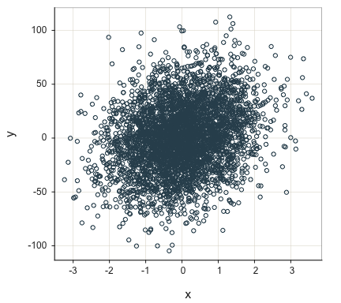

```
## --- Pearson's product-moment correlation ---
##
## Number of paired values with neither missing, n = 4000
## Sample Correlation of x and y: r = 0.251
##
## Hypothesis Test of 0 Correlation:  t = 16.397,  df = 3998,  p-value = 0.000
## 95% Confidence Interval for Correlation:  0.222 to 0.280
##
```

```r
Plot(x, y, transparency=0.95)
```

Another way to visualize a relationship when there are many data points is to bin the *x*-axis. Specify the number of bins with parameter `n_bins`. Plot() then computes the mean of *y* for each bin and connects the means by line segments. This procedure plots the conditional means by default without any assumption of form such as linearity. Specify the `stat` parameter for `median` to compute the median of y for each bin. The standard `Plot()` parameters `fill`, `color`, `size` and `segments` also apply.

```
## >>> Note: x is not in a data frame (table)
## >>> Note: y is not in a data frame (table)
```

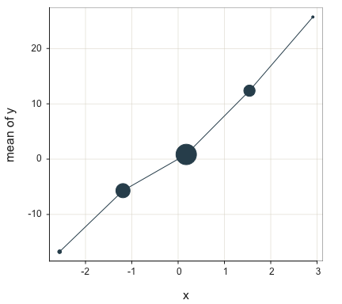

```
##
## Table: Summary Stats
##
##                x          y
## -------  -------  ---------
## n           4000       4000
## n.miss         0          0
## min       -3.239   -104.740
## max        3.589    112.460
## mean      -0.003      1.006
##
##
## Table: mean of y for levels of x
##
##                   bin      n    midpt      mean
## ---  ----------------  -----  -------  --------
## 1     [-3.246,-1.873]    116   -2.560   -16.734
## 2     (-1.873,-0.508]   1090   -1.191    -5.699
## 3      (-0.508,0.858]   2001    0.175     0.848
## 4       (0.858,2.223]    743    1.541    12.374
## 5       (2.223,3.596]     50    2.909    25.696
```

```r
Plot(x, y, n_bins=5)
```

### One Variable

The default plot for a single continuous variable includes not only the scatterplot, but also the superimposed violin plot and box plot, with outliers identified. Call this plot the VBS plot.

```
## [Violin/Box/Scatterplot graphics from Deepayan Sarkar's lattice package]
##
## >>> Suggestions
## Plot(Salary, out_cut=2, fences=TRUE, vbs_mean=TRUE)  # Label two outliers ...
## Plot(Salary, box_adj=TRUE)  # Adjust boxplot whiskers for asymmetry
```

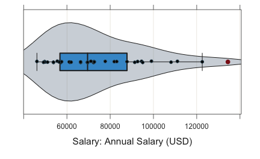

```
## --- Salary ---
## Present: 37
## Missing: 0
## Total  : 37
##
## Mean         : 73795.557
## Stnd Dev     : 21799.533
## IQR          : 31012.560
## Skew         : 0.190   [medcouple, -1 to 1]
##
## Minimum      : 46124.970
## Lower Whisker: 46124.970
## 1st Quartile : 56772.950
## Median       : 69547.600
## 3rd Quartile : 87785.510
## Upper Whisker: 122563.380
## Maximum      : 134419.230
##
##
## --- Outliers ---     from the box plot: 1
##
## Small      Large
## -----      -----
##             134419.23
##
## Number of duplicated values: 0
##
## Parameter values (can be manually set)
## -------------------------------------------------------
## size: 0.61      size of plotted points
## out_size: 0.82  size of plotted outlier points
## jitter_y: 0.45 random vertical movement of points
## jitter_x: 0.00  random horizontal movement of points
## bw: 9529.04       set bandwidth higher for smoother edges
```

```r
Plot(Salary)
```

Control the choice of the three superimposed plots – violin, box, and scatter – with the `vbs_plot` parameter. The default setting is `"vbs"` for all three plots. Here, for example, obtain just the box plot. Or, use the alias `BoxPlot()` in place of `Plot()`.

```
## [Violin/Box/Scatterplot graphics from Deepayan Sarkar's lattice package]
##
## >>> Suggestions
## Plot(Salary, out_cut=2, fences=TRUE, vbs_mean=TRUE)  # Label two outliers ...
## Plot(Salary, box_adj=TRUE)  # Adjust boxplot whiskers for asymmetry
```

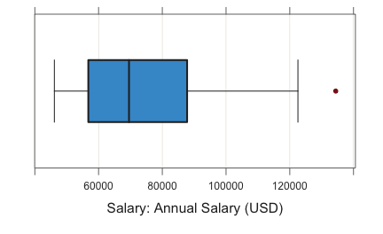

```
## --- Salary ---
## Present: 37
## Missing: 0
## Total  : 37
##
## Mean         : 73795.557
## Stnd Dev     : 21799.533
## IQR          : 31012.560
## Skew         : 0.190   [medcouple, -1 to 1]
##
## Minimum      : 46124.970
## Lower Whisker: 46124.970
## 1st Quartile : 56772.950
## Median       : 69547.600
## 3rd Quartile : 87785.510
## Upper Whisker: 122563.380
## Maximum      : 134419.230
##
##
## --- Outliers ---     from the box plot: 1
##
## Small      Large
## -----      -----
##             134419.23
##
## Number of duplicated values: 0
```

```r
Plot(Salary, vbs_plot="b")
```

Do a frequency distribution by specifying the value of parameter `stat_x`, either `"count"` or if the y-axis is proportion, then `"proportion"` or `"%"`. Can specify a custom bin width if desired with the parameter `bin_width`.

```
## >>> Suggestions
## Plot(Salary, stat_x="%", bin_width=13000, size=0)  # just line segments, no points
##
## --- Salary ---
##
##      n   miss         mean           sd          min          mdn          max
##      37      0    73795.557    21799.533    46124.970    69547.600   134419.230
##
##
## Bin Width: 13000
## Number of Bins: 8
##
##              Bin  Midpnt  Count    Prop  Cumul.c  Cumul.p
## ---------------------------------------------------------
##   40000 >  53000   46500      5    0.14        5     0.14
##   53000 >  66000   59500     10    0.27       15     0.41
##   66000 >  79000   72500     10    0.27       25     0.68
##   79000 >  92000   85500      4    0.11       29     0.78
##   92000 > 105000   98500      4    0.11       33     0.89
##  105000 > 118000  111500      2    0.05       35     0.95
##  118000 > 131000  124500      1    0.03       36     0.97
##  131000 > 144000  137500      1    0.03       37     1.00
##
## No (Box plot) outliers
```

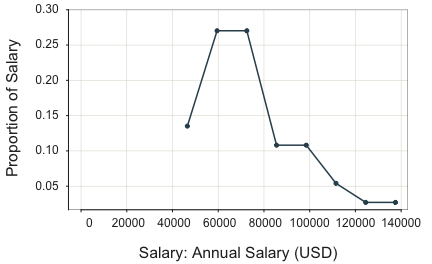

```r
Plot(Salary, stat_x="%", bin_width=13000)
```

### Cleveland Dot Plot

Create a Cleveland dot plot when one of the variables has unique (ID) values. In this example, for a single variable, row names are on the y-axis. The default plots sorts by the value plotted with the default value of parameter `sort_yx` of `"+"` for an ascending plot. Set to `"-"` for a descending plot and `"0"` for no sorting.

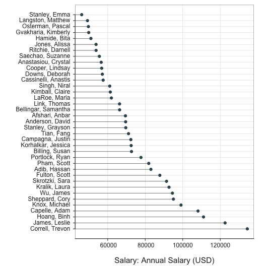

```
##
## --- Salary ---
##
##      n   miss      mean        sd       min       mdn       max
##      37      0   73795.6   21799.5   46125.0   69547.6  134419.2
##
##
## --- Outliers ---     from the box plot: 1
##
## Small      Large
## -----      -----
##             134419.2
##
## Some Parameter values (can be manually set)
## -------------------------------------------------------
## size: 0.80  size of plotted points
## jitter_y: 0.00  random vertical movement of points
## jitter_x: 0.00  random horizontal movement of points
```

```r
Plot(Salary, row_names)
```

The standard scatterplot version of a Cleveland dot plot follows, with no sorting and no line segments.

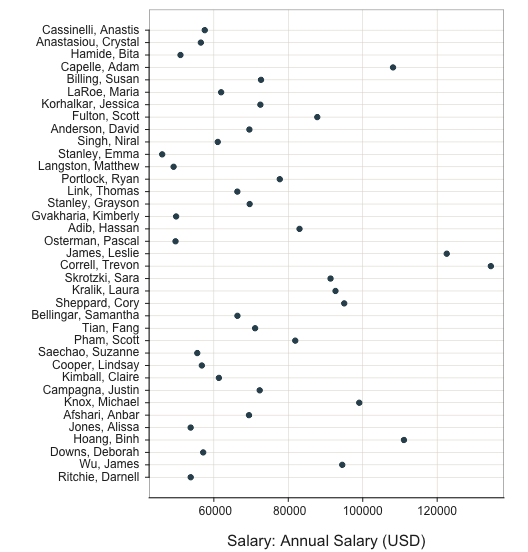

```
##
## --- Salary ---
##
##      n   miss      mean        sd       min       mdn       max
##      37      0   73795.6   21799.5   46125.0   69547.6  134419.2
##
##
## --- Outliers ---     from the box plot: 1
##
## Small      Large
## -----      -----
##             134419.2
##
## Some Parameter values (can be manually set)
## -------------------------------------------------------
## size: 0.80  size of plotted points
## jitter_y: 0.00  random vertical movement of points
## jitter_x: 0.00  random horizontal movement of points
```

```r
Plot(Salary, row_names, sort_yx="0", segments_y=FALSE)
```

This Cleveland dot plot has two x-variables, indicated as a standard R vector with the `c()` function. In this situation, the two points on each row are connected with a line segment. By default the rows are sorted by distance between the successive points.

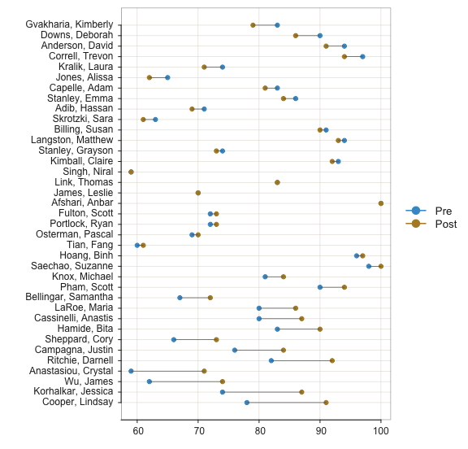

```
##
## --- Pre ---
##
##      n   miss    mean      sd     min     mdn     max
##      37      0    78.8    12.0    59.0    80.0   100.0
##
##
## --- Post ---
##
##      n   miss    mean      sd     min     mdn     max
##      37      0    81.0    11.6    59.0    84.0   100.0
##
## Some Parameter values (can be manually set)
## -------------------------------------------------------
## size: 0.80  size of plotted points
## jitter_y: 0.00  random vertical movement of points
## jitter_x: 0.00  random horizontal movement of points
```

```r
Plot(c(Pre, Post), row_names)
```

## Categorical and Continuous Variables

A mixture of categorical and continuous variables can be plotted a variety of ways, as illustrated below.

### Two Continuous, One Categorical

Plot a scatterplot of two continuous variables for each level of a categorical variable on the same panel with the `by` parameter. Here, plot *Years* and *Salary* each for the two levels of *Gender* in the data. Colors and geometric plot shapes can distinguish between the plots. For all variables except an ordered factor, the default plots according to the default qualitative color palette, `"hues"`, with the geometric shape of a point.

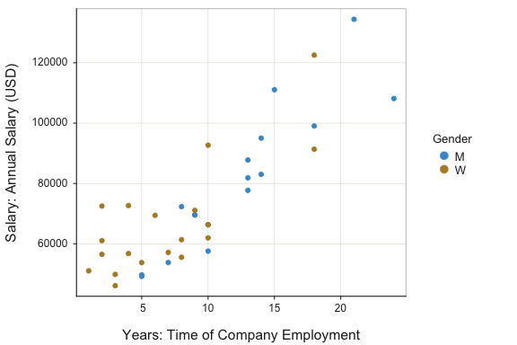

```r
Plot(Years, Salary, by=Gender)
```

Change the plot colors with the `fill` (interior) and `color` (exterior or edge) parameters. Because there are two levels of the `by` variable, specify two fill colors and two edge colors each with an R vector defined by the `c()` function. Also, include the regression line for each group with the `fit` parameter and increase the size of the plotted points with the `size` parameter.

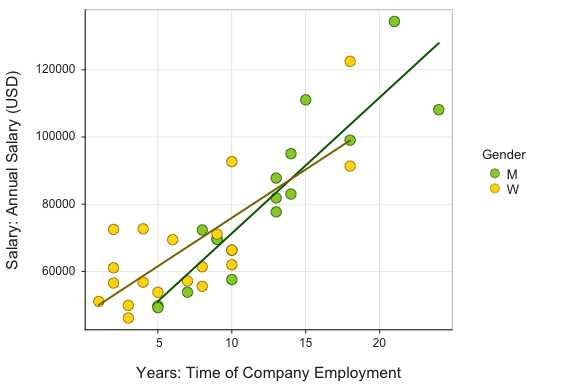

```
##
## Gender: M   Line: b0 = 30842.335    b1 = 4047.307    Fit: MSE = 107,647,877   Rsq = 0.819
##
## Gender: W   Line: b0 = 47109.787    b1 = 2882.272    Fit: MSE = 144,700,625   Rsq = 0.598
##
```

```r
Plot(Years, Salary, by=Gender, size=2, fit="lm",
     fill=c("olivedrab3", "gold1"),
     color=c("darkgreen", "gold4")
)
```

Change the plotted shapes with the `shape` parameter. The default value is `"circle"` with both an exterior color and filled interior, specified with `"color"` and `"fill"`. Other possible values, with fillable interiors, are `"circle"`, `"square"`, `"diamond"`, `"triup"` (triangle up), and `"tridown"` (triangle down). Other possible values include all uppercase and lowercase letters, all digits, and most punctuation characters. The numbers 0 through 25 defined by the R `points()` function also apply. If plotting levels according to `by`, then list one shape for each level to be plotted.

Or, request default shapes across the different `by` groups by setting parameter `shapes` to `"vary"`.

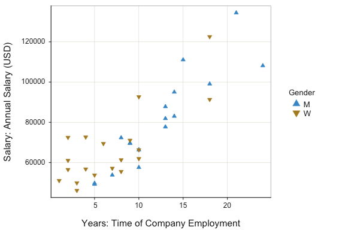

```r
Plot(Years, Salary, by=Gender, shape="vary")
```

A Trellis (facet) plot creates a separate panel for the plot of each level of the categorical variable. Generate Trellis plots with the `by1` parameter. In this example, plot the best-fit linear model for the data in each panel according to the `fit` parameter. By default, the 95% confidence interval for each line is also displayed.

```
## [Trellis graphics from Deepayan Sarkar's lattice package]
```

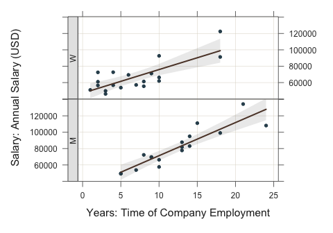

```
##
## Regression analysis of linearized Salary values
## Need back transformation of regression model to compute predicted values
##
## Gender 1  Line: b0 = 30842.335  b1 = 4047.307   Fit: MSE = 107,647,877   Rsq = 0.819
##
## Gender 2  Line: b0 = 47109.787  b1 = 2882.272   Fit: MSE = 144,700,625   Rsq = 0.598
```

```r
Plot(Years, Salary, by1=Gender, fit="lm")
```

Turn off the confidence interval by setting the parameter `fit_se` to 0 for the value of the confidence level.

### One Continuous, One Categorical

A categorical variable plotted with a continuous variable results in a traditional scatterplot though, of course, the scatter is confined to the straight lines that represent the levels of the categorical variable, its values.

The first two parameters of `Plot()` are `x` and `y`. In this example, the categorical variable, *Dept*, listed second, specifies the `y` variable, as in *y=Dept*. There is no distinction in this function call for two continues variables or one continuous and one categorical. The `Plot()` function evaluates each variable for continuity and responds appropriately.

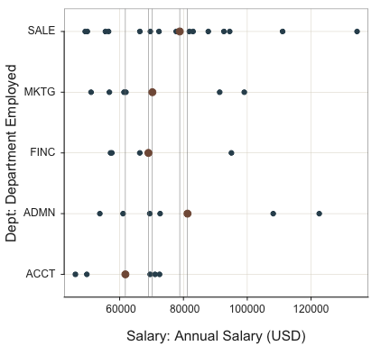

```
## Salary: Annual Salary (USD)
##   - by levels of -
## Dept: Department Employed
##
##        n   miss      mean        sd       min       mdn       max
## ACCT    5      0   61792.8   12774.6   46125.0   69547.6   72502.5
## ADMN    6      0   81277.1   27585.2   53788.3   71058.6  122563.4
## FINC    4      0   69010.7   17852.5   57139.9   61937.6   95027.6
## MKTG    6      0   70257.1   19869.8   51036.8   61659.0   99062.7
## SALE   15      0   78830.1   23476.8   49189.0   77714.9  134419.2
##
## Some Parameter values (can be manually set)
## -------------------------------------------------------
## size: 0.80  size of plotted points
## jitter_y: 0.00  random vertical movement of points
## jitter_x: 0.00  random horizontal movement of points
```

```r
Plot(Salary, Dept)
```

To avoid point overlap, if there is at least one duplicated value of continuous `y` for any level of categorical `x`, by default some horizontal jitter for each plotted point is added, which was not needed in this example. Manually adjust the jitter with either parameter `jitter_x` or, if `x` is continuous and `y` categorical, the `jitter_y` parameter. In addition, if the categorical variable is an R `factor` or a variable of type `character`, by default the mean of the continuous variable is displayed at each level of the categorical variable, as well in the text output. If the categorical variable is numeric, better to convert the variable to a factor to have just the categories on the axis and not a continuous scale. For example, `d$Gender <- factor(d$Gender)`.

Another helpful technique for large data sets is to add some fill transparency with the `transparency` parameter, with values such as 0.8 and 0.9. The combination of jitter and transparency allows for plotting many thousands of points.

An alternative display of the distribution of a continuous variable and a categorical variable is a superimposed violin, box, and scatter plot, a VBS plot. To plot the points in different colors according to the level of the categorical variable, invoke the `by` parameter. Here, plot *Salary* across the levels of *Gender* on the same panel.

```
## [Violin/Box/Scatterplot graphics from Deepayan Sarkar's lattice package]
##
## >>> Suggestions
## Plot(Salary, out_cut=2, fences=TRUE, vbs_mean=TRUE)  # Label two outliers ...
## Plot(Salary, box_adj=TRUE)  # Adjust boxplot whiskers for asymmetry
## ttest(Salary ~ Gender)  # Add the data parameter if not the d data frame
```

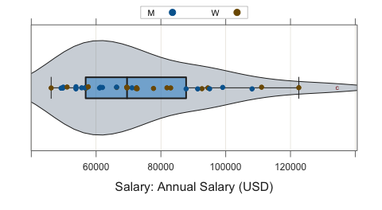

```
## Salary: Annual Salary (USD)
##   - by levels of -
## Gender
##
##      n   miss         mean           sd          min          mdn          max
## M   18      0    81147.458    23128.436    49188.960    79792.950   134419.230
## W   19      0    66830.598    18438.456    46124.970    61356.690   122563.380
##
##        Max Dupli-
## Level   cations   Values
## ------------------------------
## M           0
## W           0
##
## Parameter values (can be manually set)
## -------------------------------------------------------
## size: 0.56      size of plotted points
## out_size: 0.80  size of plotted outlier points
## jitter_y: 0.54 random vertical movement of points
## jitter_x: 0.00  random horizontal movement of points
## bw: 9529.04       set bandwidth higher for smoother edges
```

```r
Plot(Salary, by=Gender)
```

```
## [Trellis graphics from Deepayan Sarkar's lattice package]
##
## >>> Suggestions
## Plot(Salary, out_cut=2, fences=TRUE, vbs_mean=TRUE)  # Label two outliers ...
## Plot(Salary, box_adj=TRUE)  # Adjust boxplot whiskers for asymmetry
## ttest(Salary ~ Gender)  # Add the data parameter if not the d data frame
```

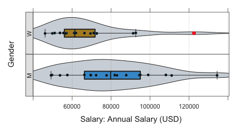

```
## Salary: Annual Salary (USD)
##   - by levels of -
## Gender: Man or Woman
##
##      n   miss         mean           sd          min          mdn          max
## M   18      0    81147.458    23128.436    49188.960    79792.950   134419.230
## W   19      0    66830.598    18438.456    46124.970    61356.690   122563.380
##
##        Max Dupli-
## Level   cations   Values
## ------------------------------
## M           0
## W           0
##
## Parameter values (can be manually set)
## -------------------------------------------------------
## size: 0.56      size of plotted points
## out_size: 0.80  size of plotted outlier points
## jitter_y: 0.54 random vertical movement of points
## jitter_x: 0.00  random horizontal movement of points
## bw: 9529.04       set bandwidth higher for smoother edges
```

```r
Plot(Salary, by1=Gender)
```

The default coloring of the boxes for variables other than an ordered factor follows the default qualitative palette, `"hues"`. For an ordered factor, the fill color follows the default sequential palette of the corresponding theme, such as `"blues"`. Customize colors with the `box_fill` parameter.

Just show the box plots according to the `vbs_plot` parameter, which has a default setting of `vbs` for the superimposed violin, box, and scatter plots. Set `vbs_plot` to `"b"`. Or, use the alias `BoxPlot()`. Change the fill color of each box with the `box_fill` parameter. In addition to the traditional median for a box plot, show the mean as well as with the `vbs_mean` parameter. If specifying just one fill color, then all boxes are filled with that color.

Or, drop the box plot and only plot the violins and the scatter plots. Without the boxes, the violins take on the default colors. Specify a value of `"vs"` for the `vbs_plot` parameter. If only plotting the violins, then can also use the alias `ViolinPlot()`. Change the fill color of the violins with parameter `violin_fill`.

```
## [Trellis graphics from Deepayan Sarkar's lattice package]
##
## >>> Suggestions
## Plot(Salary, out_cut=2, fences=TRUE, vbs_mean=TRUE)  # Label two outliers ...
## Plot(Salary, box_adj=TRUE)  # Adjust boxplot whiskers for asymmetry
## ttest(Salary ~ Gender)  # Add the data parameter if not the d data frame
```

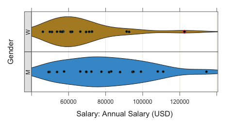

```
## Salary: Annual Salary (USD)
##   - by levels of -
## Gender: Man or Woman
##
##      n   miss         mean           sd          min          mdn          max
## M   18      0    81147.458    23128.436    49188.960    79792.950   134419.230
## W   19      0    66830.598    18438.456    46124.970    61356.690   122563.380
##
##        Max Dupli-
## Level   cations   Values
## ------------------------------
## M           0
## W           0
##
## Parameter values (can be manually set)
## -------------------------------------------------------
## size: 0.56      size of plotted points
## out_size: 0.80  size of plotted outlier points
## jitter_y: 0.54 random vertical movement of points
## jitter_x: 0.00  random horizontal movement of points
## bw: 9529.04       set bandwidth higher for smoother edges
```

```r
Plot(Salary, by1=Gender, vbs_plot="vs")
```

The following plot uses the alias `BoxPlot()` to generate a Trellis plot of boxplots only across the levels of *Gender*.

```
## [Trellis graphics from Deepayan Sarkar's lattice package]
##
## >>> Suggestions
## Plot(Salary, out_cut=2, fences=TRUE)  # Label two outliers ...
## Plot(Salary, box_adj=TRUE)  # Adjust boxplot whiskers for asymmetry
## ttest(Salary ~ Gender)  # Add the data parameter if not the d data frame
```

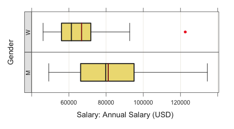

```
## Salary: Annual Salary (USD)
##   - by levels of -
## Gender: Man or Woman
##
##      n   miss         mean           sd          min          mdn          max
## M   18      0    81147.458    23128.436    49188.960    79792.950   134419.230
## W   19      0    66830.598    18438.456    46124.970    61356.690   122563.380
##
##        Max Dupli-
## Level   cations   Values
## ------------------------------
## M           0
## W           0
```

```r
BoxPlot(Salary, by1=Gender, vbs_mean=TRUE, box_fill="lightgoldenrod")
```

Show the different distributions of the continuous variable across the levels of the categorical variable with a scatterplot. Here, show the distribution of *Salary* for Males and Females across the various departments.

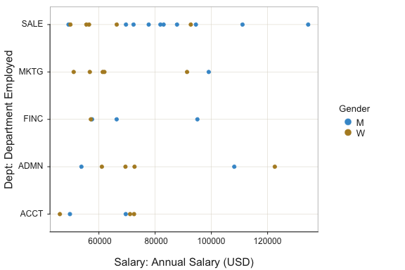

```
## Salary: Annual Salary (USD)
##   - by levels of -
## Dept: Department Employed
##
##        n   miss      mean        sd       min       mdn       max
## ACCT    5      0   61792.8   12774.6   46125.0   69547.6   72502.5
## ADMN    6      0   81277.1   27585.2   53788.3   71058.6  122563.4
## FINC    4      0   69010.7   17852.5   57139.9   61937.6   95027.6
## MKTG    6      0   70257.1   19869.8   51036.8   61659.0   99062.7
## SALE   15      0   78830.1   23476.8   49189.0   77714.9  134419.2
##
## Some Parameter values (can be manually set)
## -------------------------------------------------------
## size: 0.80  size of plotted points
## jitter_y: 0.00  random vertical movement of points
## jitter_x: 0.00  random horizontal movement of points
```

```r
Plot(Salary, Dept, by=Gender)
```

### One Continuous, Two Categorical

To do a Trellis plot with two categorical variables, invoke the `by2` parameter in addition to the `by1` parameter. By default, the box fill colors are unique for each level of the `by1` variable, and then the colors cycle through all the values of the `by2` variable. With so many panels to plot, explicitly set them in a single column by setting parameter `n_col` to `1`. The corresponding row parameter is `n_row`.

```
## [Trellis graphics from Deepayan Sarkar's lattice package]
##
## >>> Suggestions
## Plot(Salary, out_cut=2, fences=TRUE, vbs_mean=TRUE)  # Label two outliers ...
## Plot(Salary, box_adj=TRUE)  # Adjust boxplot whiskers for asymmetry
## ttest(Salary ~ Gender)  # Add the data parameter if not the d data frame
```

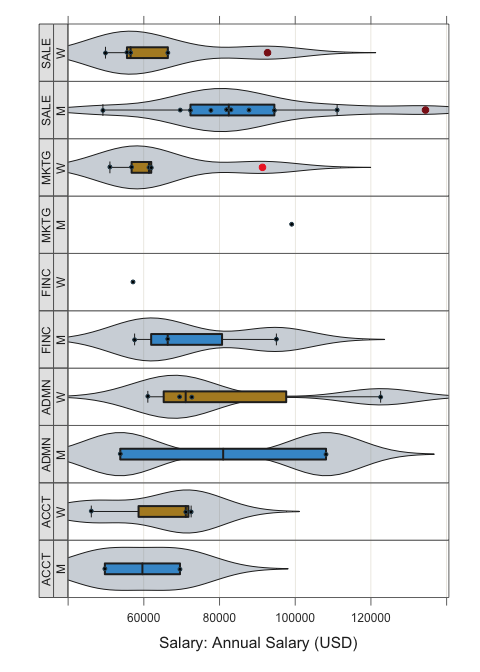

```
## Salary: Annual Salary (USD)
##   - by levels of -
## Gender: Man or Woman
##
##      n   miss         mean           sd          min          mdn          max
## M   18      0    81147.458    23128.436    49188.960    79792.950   134419.230
## W   19      0    66830.598    18438.456    46124.970    61356.690   122563.380
##
##        Max Dupli-
## Level   cations   Values
## ------------------------------
## M           0
## W           0
##
## Parameter values (can be manually set)
## -------------------------------------------------------
## size: 0.56      size of plotted points
## out_size: 0.80  size of plotted outlier points
## jitter_y: 0.54 random vertical movement of points
## jitter_x: 0.00  random horizontal movement of points
## bw: 9529.04       set bandwidth higher for smoother edges
```

```r
Plot(Salary, by1=Gender, by2=Dept, n_col=1)
```

```
## [Trellis graphics from Deepayan Sarkar's lattice package]
##
## >>> Suggestions
## Plot(Salary, out_cut=2, fences=TRUE, vbs_mean=TRUE)  # Label two outliers ...
## Plot(Salary, box_adj=TRUE)  # Adjust boxplot whiskers for asymmetry
## ttest(Salary ~ Gender)  # Add the data parameter if not the d data frame
## ANOVA(Salary ~ Dept)  # Add the data parameter if not the d data frame
```

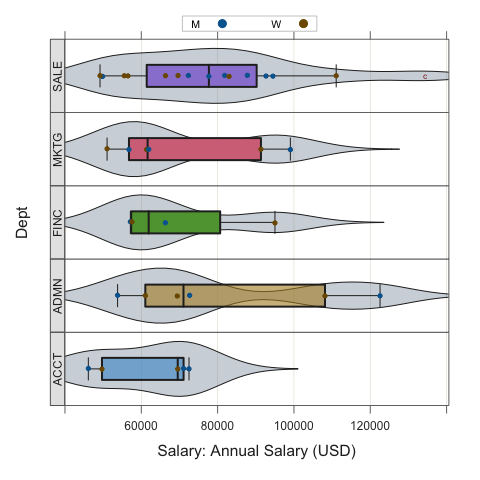

```
## Salary: Annual Salary (USD)
##   - by levels of -
## Gender: Department Employed
##
##        n   miss         mean           sd          min          mdn          max
## ACCT    5      0    61792.776    12774.606    46124.970    69547.600    72502.500
## ADMN    6      0    81277.117    27585.151    53788.260    71058.595   122563.380
## FINC    4      0    69010.675    17852.498    57139.900    61937.625    95027.550
## MKTG    6      0    70257.128    19869.812    51036.850    61658.990    99062.660
## SALE   15      0    78830.065    23476.839    49188.960    77714.850   134419.230
##
##        Max Dupli-
## Level   cations   Values
## ------------------------------
## ACCT        0
## ADMN        0
## FINC        0
## MKTG        0
## SALE        0
##
## Parameter values (can be manually set)
## -------------------------------------------------------
## size: 0.52      size of plotted points
## out_size: 0.79  size of plotted outlier points
## jitter_y: 0.50 random vertical movement of points
## jitter_x: 0.00  random horizontal movement of points
## bw: 9529.04       set bandwidth higher for smoother edges
```

```r
Plot(Salary, by1=Dept, by=Gender, n_col=1)
```

### Two Continuous, Three Categorical

`Plot()` can display the relationships for up to five variables. The two primary variables, *x* and *y*, that form the basis of the scatter plot, are continuous. Usually these two variables are listed first in the function call and so do not need their parameter names specified. Indicate two categorical variables that form the Trellis panels with parameters `by1` and `by2`. Call these two variables the Trellis variables, which define a Trellis panel for each combination of their values. Finally, there can be a categorical grouping variable, the `by` variable, which plots different groups within each Trellis panel.

To illustrate, first, the data. Use the Cars93 data set that is installed with **lessR**, which describes characteristics of 1993 cars.

```r
d <- Read("Cars93")
```

```
##
## >>> Suggestions
## Recommended binary format for data files: feather
##   Create with Write(d, "your_file", format="feather")
## More details about your data, Enter:  details()  for d, or  details(name)
##
## Data Types
## ------------------------------------------------------------
## character: Non-numeric data values
## integer: Numeric data values, integers only
## double: Numeric data values with decimal digits
## ------------------------------------------------------------
##
##       Variable                  Missing  Unique
##           Name     Type  Values  Values  Values   First and last values
## ------------------------------------------------------------------------------------------
##  1        Make character     93       0      32   Acura  Acura ... Volvo  Volvo
##  2        Type character     93       0       6   Small  Midsize ... Compact  Midsize
##  3    MinPrice    double     93       0      79   12.9  29.2  25.9 ... 22.9  21.8  24.8
##  4    MidPrice    double     93       0      81   15.9  33.9  29.1 ... 23.3  22.7  26.7
##  5    MaxPrice    double     93       0      79   18.8  38.7  32.3 ... 23.7  23.5  28.5
##  6     MPGcity   integer     93       0      21   25  18  20 ... 18  21  20
##  7    MPGhiway   integer     93       0      22   31  25  26 ... 25  28  28
##  8     Airbags   integer     93       0       3   0  2  1 ... 0  1  2
##  9  DriveTrain   integer     93       0       3   1  1  1 ... 1  0  1
## 10   Cylinders   integer     92       1       5   4  6  6 ... 6  4  5
## 11      Engine    double     93       0      26   1.8  3.2  2.8 ... 2.8  2.3  2.4
## 12          HP   integer     93       0      57   140  200  172 ... 178  114  168
## 13         RPM   integer     93       0      24   6300  5500  5500 ... 5800  5400  6200
## 14     RevMile   integer     93       0      78   2890  2335  2280 ... 2385  2215  2310
## 15      Manual   integer     93       0       2   1  1  1 ... 1  1  1
## 16     FuelCap    double     93       0      38   13.2  18  16.9 ... 18.5  15.8  19.3
## 17     PassCap   integer     93       0       6   5  5  5 ... 4  5  5
## 18      Length   integer     93       0      51   177  195  180 ... 159  190  184
## 19   Wheelbase   integer     93       0      27   102  115  102 ... 97  104  105
## 20       Width   integer     93       0      16   68  71  67 ... 66  67  69
## 21       Uturn   integer     93       0      14   37  38  37 ... 36  37  38
## 22    RearSeat    double     91       2      24   26.5  30  28 ... 26  29.5  30
## 23      LugCap   integer     82      11      16   11  15  14 ... 15  14  15
## 24      Weight   integer     93       0      81   2705  3560  3375 ... 2810  2985  3245
## 25      Source   integer     93       0       2   0  0  0 ... 0  0  0
## ------------------------------------------------------------------------------------------
```

The categorical variables are integer coded 0 and 1, so recode to R factors to obtain more descriptive labels.

```r
d$Transmission <- factor(d$Manual, levels=0:1, labels=c("Auto", "Manual"))
d$Source <- factor(d$Source, levels=0:1, labels=c("Foreign", "Domestic"))
```

Plot MPGcity according to Weight. Specify the number of Cylinders and Manual transmission or not as Trellis conditioning variables to form the Trellis plot. Specify the Source of the vehicle, Foreign or Domestic as a grouping variable to plot with separate colors on each panel.

```
## [Trellis graphics from Deepayan Sarkar's lattice package]
```

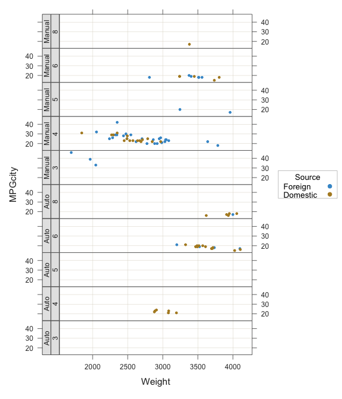

```r
Plot(Weight, MPGcity, by1=Cylinders, by2=Transmission, by=Source, n_col=1)
```

From the visualization the patterns emerge. As Weight increases city MPG decreases. Domestic cars tend to weigh more. Foreign cars tend to have fewer cylinders, which also leads to better fuel mileage.